# Guidelines for Oral Presentations (RR1)

This presentation represents 25% of the grade for Research Report 1. The 5 points are distributed as follows. Make sure your presentation fits all the criteria below.

*NB: To recap on how to use ggplot for making graphs, I strongly recommend reading this chapter again: https://r4ds.hadley.nz/data-visualize.html*

## Grading

### Formatting (2 pts)

- The presentation consists of a single slide, which includes:
  - *(Optional)* the research question, as a title
  - a plot of your main result. Only one plot is allowed. The plot can have multiple panels only in one case: when each panel corresponds to a different code.
  - text is allowed on the plot if it’s information about the axes, categories, panels or colors. The plot shouldn’t have a title or a legend (you will explain the details orally).
  - nothing else appears on the slide.
  - The plot should be colored (see examples below)
- The presentation lasts a maximum of 5 minutes. You are strongly encouraged to aim for slightly less. You won’t be sanctioned for finishing early, but you will be penalized if you go even 5 seconds over 5 minutes. Mastering your time is important.

### Clarity of presentation (3 pts)

- You speak clearly to the audience:
  - you don’t read your notes
  - you look at the audience, not at the professor
  - you speak in a way that will be easily understood by your audience. You may speak in English or French.
- You present the plot clearly. When describing it, I recommend you follow this order (the order itself is optional, but each component must be present):
  - **Present the axes.** State what variables appear on the x- and y-axes. If there are units, specify them (e.g. thousands of dirhams, cm).
  - **Explain what the marks represent.** If there are dots on the plot, say what each one stands for (e.g. “each dot represents one individual: the x-axis is their monthly income and the y-axis is their number of years of education”).
  - **Name and describe the visualization type.** Every time, you need to explain how to read the visualization. A few examples:
    - boxplot: explain how to interpret it (e.g. this line is the median, this one is the 1st quartile…)
    - bar plot: explain what the bars represent, and what the bin widths represent (give a bit of detail here)
    - any curve or line: explain how it was constructed (e.g. a fitted linear model, or a curve fitted with LOESS)
    - etc.
  - **Present what is interesting.** Once the plot is clearly described, point to what the result shows (e.g. “this graph shows a clear linear association between size and weight of individuals in my dataset”).

## Example

Suppose your research question is: **Did rich people survive the Titanic more than poor people?** Below are examples of what is allowed and what is not.

### ✅ Allowed: a single plot

A boxplot of fare paid by survival status. One plot, no panels — this is fine.

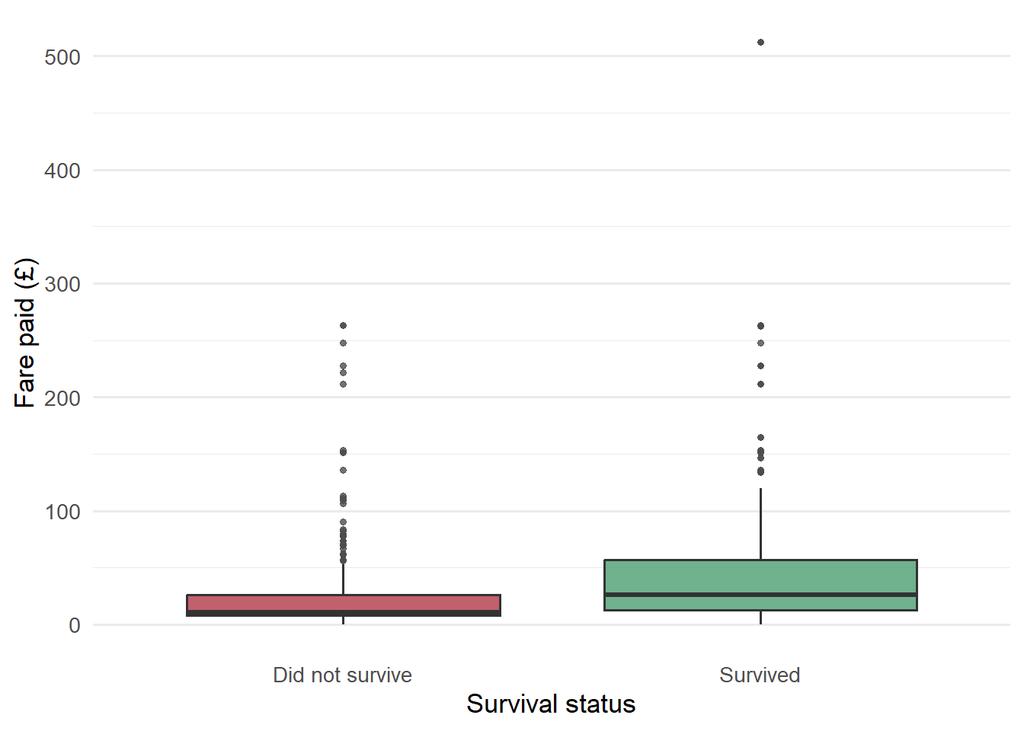

```r
library(ggplot2)
data <- read.csv("titanic.csv")
data$Survived <- factor(data$Survived,
                        levels = c(0, 1),
                        labels = c("Did not survive", "Survived"))

ggplot(data, aes(x = Survived, y = Fare, fill = Survived)) +
  geom_boxplot(alpha = 0.8, outlier.colour = "grey30", outlier.size = 1.2) +
  scale_fill_manual(values = c("Did not survive" = "#B23A48",
                               "Survived"        = "#4C9F70")) +
  labs(x = "Survival status", y = "Fare paid (£)") +
  theme_minimal(base_size = 13) +
  theme(legend.position = "none",
        panel.grid.major.x = element_blank())
```

### ✅ Allowed: panels, panels represent the same analysis but on sub-groups of the same category

If you want to show the same relationship separately for each passenger class, you can use panels, because you’re making the same analysis for different sub-groups of the same category (here: passenger class).

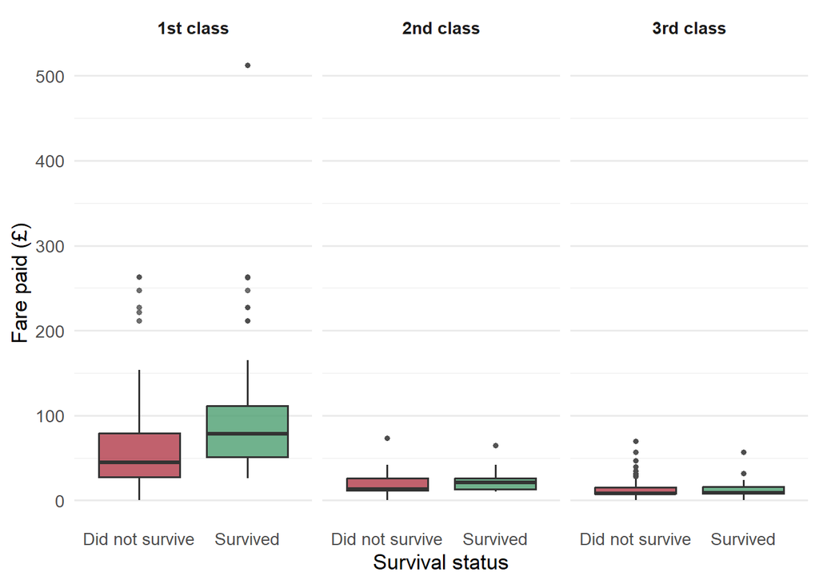

```r
data$PclassLabel <- factor(data$Pclass,
                           levels = c(1, 2, 3),
                           labels = c("1st class", "2nd class", "3rd class"))

ggplot(data, aes(x = Survived, y = Fare, fill = Survived)) +
  geom_boxplot(alpha = 0.8, outlier.colour = "grey30", outlier.size = 1.2) +
  facet_wrap(~ PclassLabel) +
  scale_fill_manual(values = c("Did not survive" = "#B23A48",
                               "Survived"        = "#4C9F70")) +
  labs(x = "Survival status", y = "Fare paid (£)") +
  theme_minimal(base_size = 13) +
  theme(legend.position = "none",
        panel.grid.major.x = element_blank(),
        strip.text = element_text(face = "bold"))
```

### ❌ Not allowed: two plots side by side

Here, you have two panels representing fare by survival and survival rate by sex. These count as **two different plots**, because you’re running two distinct sub-group analyses: one where you see how your relationship changes by fare, and the other by sex.

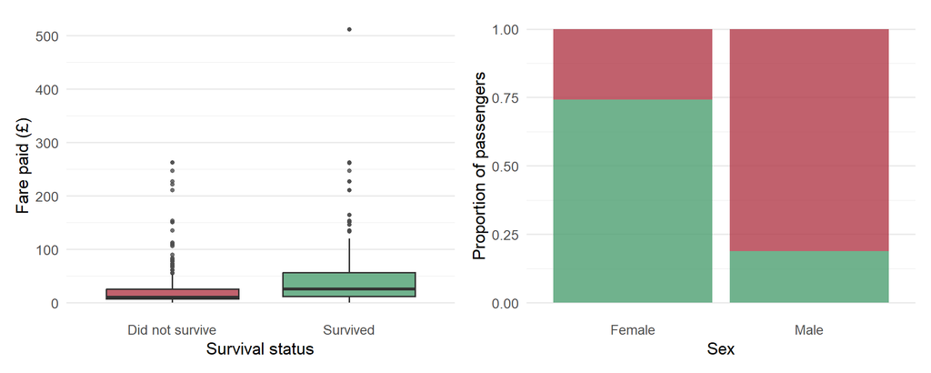

```r
library(patchwork)

data$SexLabel <- factor(data$Sex,
                        levels = c("female", "male"),
                        labels = c("Female", "Male"))

p1 <- ggplot(data, aes(x = Survived, y = Fare, fill = Survived)) +
  geom_boxplot(alpha = 0.8, outlier.colour = "grey30", outlier.size = 1.2) +
  scale_fill_manual(values = c("Did not survive" = "#B23A48",
                               "Survived"        = "#4C9F70")) +
  labs(x = "Survival status", y = "Fare paid (£)") +
  theme_minimal(base_size = 13) +
  theme(legend.position = "none",
        panel.grid.major.x = element_blank())

p2 <- ggplot(data, aes(x = SexLabel, fill = Survived)) +
  geom_bar(position = "fill", alpha = 0.8) +
  scale_fill_manual(values = c("Did not survive" = "#B23A48",
                               "Survived"        = "#4C9F70")) +
  labs(x = "Sex", y = "Proportion of passengers") +
  theme_minimal(base_size = 13) +
  theme(legend.position = "none",
        panel.grid.major.x = element_blank())

p1 + p2
```

## Examples of a good oral presentation

### Example 1: Boxplot

Here is roughly what a good 5-minute presentation of the first plot above would sound like:

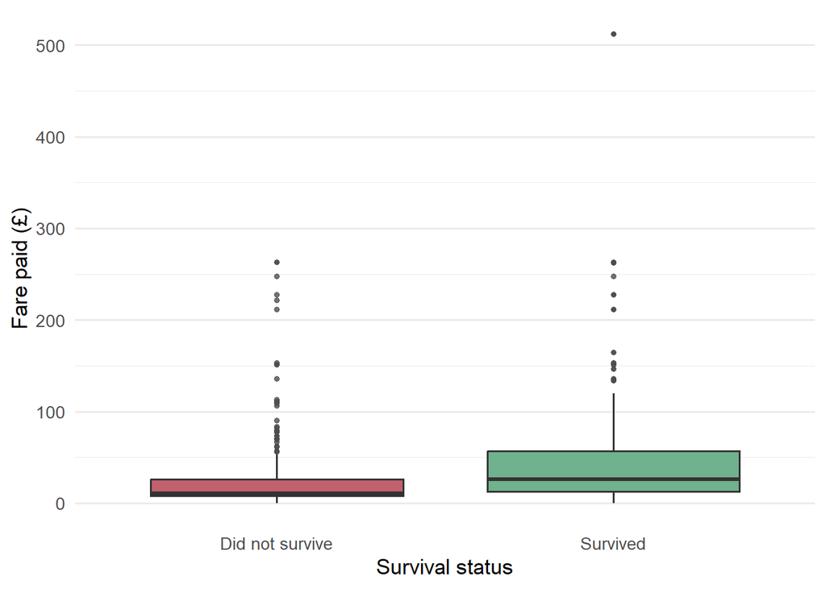

```r
library(ggplot2)
data <- read.csv("titanic.csv")
data$Survived <- factor(data$Survived,
                        levels = c(0, 1),
                        labels = c("Did not survive", "Survived"))

ggplot(data, aes(x = Survived, y = Fare, fill = Survived)) +
  geom_boxplot(alpha = 0.8, outlier.colour = "grey30", outlier.size = 1.2) +
  scale_fill_manual(values = c("Did not survive" = "#B23A48",
                               "Survived"        = "#4C9F70")) +
  labs(x = "Survival status", y = "Fare paid (£)") +
  theme_minimal(base_size = 13) +
  theme(legend.position = "none",
        panel.grid.major.x = element_blank())
```

> “My research question was whether rich people were more likely to survive the Titanic accident. My hypothesis is that rich people survived more, because they may have had safer rooms, and more social network, which could have helped them to get access to safety boats faster than poorer passengers.

> I use a dataset of Titanic passengers. I have data on who survived or not, and I operationalize being rich as the fare paid, assuming that people who bought the most expensive tickets tend to be richer.

> On this plot, the x-axis shows survival status: on the left, passengers who did not survive, on the right, passengers who did. The y-axis shows the fare they paid, in pounds.

> This is a boxplot. Each box shows the distribution of fares within one group. The thick line inside the box is the median — half the passengers paid less, half paid more. The bottom of the box is the first quartile: 25% of passengers paid less than that. The top is the third quartile: 25% paid more. So the box itself contains the middle 50% of passengers.

> The height of the box — the distance from the first to the third quartile — is called the interquartile range, or IQR. The whiskers, the lines extending above and below the box, stretch out to the furthest passengers who are still within 1.5 IQRs of the box. Anyone further out than that is plotted as an individual dot, and is conventionally called an outlier

> We see on the plot that the median fare for survivors is clearly above the median fare for non-survivors, and the whole distribution is shifted upward. This supports my hypothesis that wealthier passengers had a better chance of surviving. *(Optional)* In future work, I’d like to explore the more precise mechanisms: whether this is because rich people were in cabins closer to the lifeboats, or had priority during the evacuation.”

### Example 2: Scatterplot and linear model fit

Suppose your research question is: **Did older passengers pay more for their tickets?** You could visualize this with a scatterplot of fare against age, with a linear regression line fitted on top.

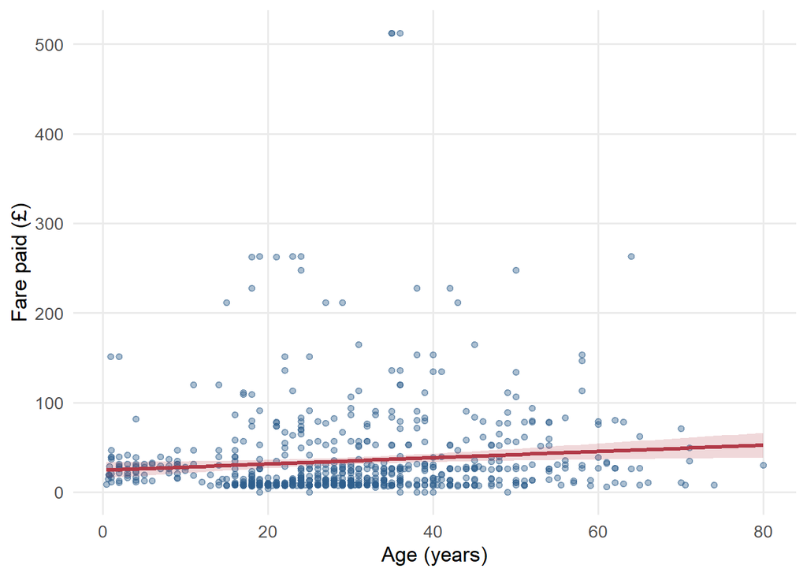

```r
ggplot(data, aes(x = Age, y = Fare)) +
  geom_point(alpha = 0.4, colour = "#2E5E8C", size = 1.5) +
  geom_smooth(method = "lm", colour = "#B23A48", fill = "#B23A48", alpha = 0.2) +
  labs(x = "Age (years)", y = "Fare paid (£)") +
  theme_minimal(base_size = 13) +
  theme(panel.grid.minor = element_blank())
```

Here is what a good oral presentation of this plot would sound like:

> “My research question was whether older passengers paid more for their Titanic tickets. My hypothesis is that older people are, on average, wealthier than younger ones — they’ve had more time to accumulate income and savings — so they might have been able to afford more expensive tickets.

> I use a dataset of Titanic passengers, with information on each passenger’s age and the fare they paid.

> On this plot, the x-axis shows age, in years. The y-axis shows the fare paid, in pounds.

> Each blue dot represents one passenger: its horizontal position is their age, and its vertical position is the fare they paid. The red line is a fitted linear regression line: it’s the straight line that best summarizes the overall relationship between age and fare in the dataset. The shaded red band around it represents the 95% confidence interval around the fit: roughly, the range of lines that would also be plausible given the data.

> We see that the line slopes slightly upward, suggesting that older passengers paid, on average, somewhat higher fares than younger ones. But the slope is modest, and the dots are very scattered around the line, which means age explains only a small part of the variation in fare. So the relationship exists, but it’s weak.”